# Data Normalization & Standardization

## Imports

```python
import pandas as pd
import numpy as np
from sklearn import set_config
from sklearn.preprocessing import StandardScaler
from sklearn.decomposition import PCA
import seaborn as sns
import matplotlib.pyplot as plt
```

We'll configure scikit-learn to output in a pandas dataframe to save us having to marry columns to numpy arrays to get DF's again

```python
set_config(transform_output="pandas")
```

Remove the target variables

```python
initial_df = pd.read_csv('HMEQ_Loss.csv')
no_targets_df = initial_df.drop(['TARGET_BAD_FLAG','TARGET_LOSS_AMT'],axis=1)
```

Split our dataset into categorical and numerical

```python
# cat only
categorical_columns = no_targets_df.select_dtypes('object')

# num only
numerical_columns = no_targets_df.select_dtypes(exclude='object')
```

## Impute missing values

For numerical, we can use the median to fill in the missing values

```python
# for our numerical friends
dropholder = []
for col in numerical_columns:
    if numerical_columns[col].isna().mean() > 0:
        numerical_columns['imp_'+col] = numerical_columns[col].fillna(numerical_columns[col].median())
        dropholder.append(col)
    else:
        continue

numerical_columns.drop(dropholder,axis=1,inplace=True)
```

For categorical, we can use the mode (aka the most frequently appearing value)

```python
# for our categorical friends
dropholder = []
for col in categorical_columns:
    if categorical_columns[col].isna().mean() > 0:
        colmode = categorical_columns[col].value_counts().index[0]
        categorical_columns['imp_'+col] = categorical_columns[col].fillna(colmode)
        dropholder.append(col)
    else:
        continue

categorical_columns.drop(dropholder,axis=1,inplace=True)
```

## Standardization

For standardization we use StandardScaler().

The formula is below:

z = (x - u) / s

Step 1 is to instantiate the Standard Scaler

```python
standardizer = StandardScaler()
standardizer.fit(numerical_columns)
```

```
StandardScaler()
```

Step 2 is to transform our numerical columns into a new dataframe called standardized

```python
standardized = standardizer.transform(numerical_columns)
standardized = standardized.add_prefix('std_')
standardized.head()
```

|  | std_LOAN | std_imp_MORTDUE | std_imp_VALUE | std_imp_YOJ | std_imp_DEROG | std_imp_DELINQ | std_imp_CLAGE | std_imp_NINQ | std_imp_CLNO | std_imp_DEBTINC |
| --- | --- | --- | --- | --- | --- | --- | --- | --- | --- | --- |
| 0 | -1.562299 | -1.107920 | -1.099371 | 0.240237 | -0.280976 | -0.375943 | -1.018026 | -0.102879 | -1.230878 | 0.106963 |
| 1 | -1.544453 | -0.069286 | -0.582794 | -0.241936 | -0.280976 | 1.477341 | -0.689350 | -0.707574 | -0.728389 | 0.106963 |
| 2 | -1.526606 | -1.398407 | -1.491970 | -0.655226 | -0.280976 | -0.375943 | -0.358680 | -0.102879 | -1.130380 | 0.106963 |
| 3 | -1.526606 | -0.187596 | -0.216389 | -0.241936 | -0.280976 | -0.375943 | -0.071488 | -0.102879 | -0.125403 | 0.106963 |
| 4 | -1.508759 | 0.582831 | 0.183939 | -0.792990 | -0.280976 | -0.375943 | -1.030391 | -0.707574 | -0.728389 | 0.106963 |

## PCA

```python
pca = PCA(n_components=standardized.shape[1])
pca.fit(standardized)
```

```
PCA(n_components=10)
```

```python
#eigen values
ev = pca.explained_variance_
ev
```

```
array([2.22473443, 1.39663279, 1.24209048, 1.00200284, 0.96019739,
       0.84828922, 0.78435407, 0.71875812, 0.62929795, 0.19532083])
```

```python
sum(pca.explained_variance_ratio_)
```

```
1.0
```

```python
varPCT = []
totPCT = []
total = 0
for i in ev:
    total = total + i
    VAR = round( i / len(ev) * 100)
    PCT = int( total / len(ev) * 100)
    varPCT.append(VAR)
    totPCT.append( PCT )
    print( round(i,2), "variation=", VAR,"%"," total=", PCT,"%")
```

```
2.22 variation= 22 %  total= 22 %
1.4 variation= 14 %  total= 36 %
1.24 variation= 12 %  total= 48 %
1.0 variation= 10 %  total= 58 %
0.96 variation= 10 %  total= 68 %
0.85 variation= 8 %  total= 76 %
0.78 variation= 8 %  total= 84 %
0.72 variation= 7 %  total= 91 %
0.63 variation= 6 %  total= 98 %
0.2 variation= 2 %  total= 100 %
```

### Scree Plots

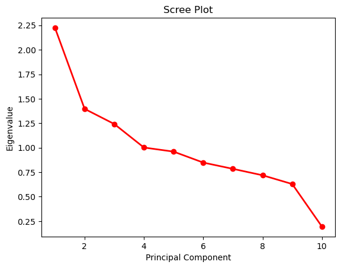

```python
PC_NUM = np.arange( standardized.shape[1] ) + 1
plt.plot( PC_NUM , ev, 'ro-', linewidth=2)
plt.title('Scree Plot')
plt.xlabel('Principal Component')
plt.ylabel('Eigenvalue')
plt.show()
```

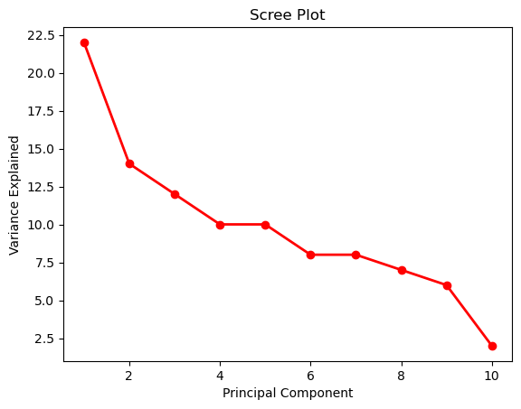

```python
plt.plot( PC_NUM , varPCT, 'ro-', linewidth=2)
plt.title('Scree Plot')
plt.xlabel('Principal Component')
plt.ylabel('Variance Explained')
plt.show()
```

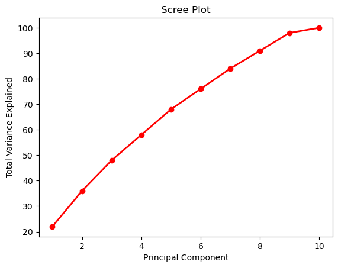

```python
plt.plot( PC_NUM , totPCT, 'ro-', linewidth=2)
plt.title('Scree Plot')
plt.xlabel('Principal Component')
plt.ylabel('Total Variance Explained')
plt.show()
```

### Weights

```python
weights_df = pd.DataFrame(pca.components_,columns=list(numerical_columns.columns))
weights_df
```

|  | LOAN | imp_MORTDUE | imp_VALUE | imp_YOJ | imp_DEROG | imp_DELINQ | imp_CLAGE | imp_NINQ | imp_CLNO | imp_DEBTINC |
| --- | --- | --- | --- | --- | --- | --- | --- | --- | --- | --- |
| 0 | 0.312234 | 0.573268 | 0.584336 | 0.035227 | -0.026401 | 0.051596 | 0.233380 | 0.046042 | 0.372511 | 0.180207 |
| 1 | -0.075215 | 0.007818 | -0.066168 | -0.320248 | 0.497790 | 0.341973 | -0.348079 | 0.512138 | 0.166219 | 0.333963 |
| 2 | -0.063091 | -0.220938 | -0.185984 | 0.510342 | 0.223492 | 0.527133 | 0.454382 | -0.031755 | 0.333920 | -0.073320 |
| 3 | 0.682854 | -0.140241 | 0.015219 | 0.459493 | 0.197542 | -0.157953 | -0.143374 | 0.336639 | -0.321572 | -0.037616 |
| 4 | -0.063696 | -0.168056 | -0.189523 | 0.219795 | -0.477461 | -0.197434 | 0.066479 | 0.216709 | 0.158053 | 0.734955 |
| 5 | 0.178176 | 0.015861 | 0.073102 | 0.098997 | 0.001593 | 0.445938 | -0.364660 | -0.631472 | -0.247145 | 0.401472 |
| 6 | 0.165340 | -0.158122 | -0.120287 | -0.222384 | 0.561617 | -0.451668 | 0.355064 | -0.363736 | 0.087704 | 0.313453 |
| 7 | -0.546504 | 0.226194 | 0.191805 | 0.556398 | 0.338371 | -0.321256 | -0.279982 | -0.050912 | -0.025648 | 0.066797 |
| 8 | -0.233301 | 0.132317 | 0.162849 | -0.061659 | 0.066171 | 0.180341 | 0.504736 | 0.200237 | -0.721712 | 0.212411 |
| 9 | -0.101716 | -0.693292 | 0.707326 | -0.060597 | -0.016689 | 0.001164 | -0.027203 | 0.023456 | 0.058452 | 0.005622 |

## Interpreting the results so far from the eigenvalues, the scree plots, and the weights

Based on the information we have so far we can determine that at 9 components, we're able to explain 98% of the variance in the data. Since 98 is good enough and adding the 10th component gives us a marginal gain of 2%, we can drop the 10th component. This allows us to reduce our overall dimensionality.

The scree plot allows us to at-a-glance confirm that going from 9 to 10 components is a marginal gain and not worth doing.

The weights tell us how important each feature was in a component. Looking at row 0 in the data frame above, we can see that VALUE was the most important feature with a weight of 0.584336. DREOG had a value of -0.026401 making it very unimportant

## Transforming our data

```python
# transform the standardized data into a pca dataframe
# drop the 10th component since the 0-9 components take us to 98% explained.
pca_df = pd.DataFrame(pca.transform(standardized))
pca_df = pca_df.iloc[:,0:9]
pca_df.head()
```

|  | pca0 | pca1 | pca2 | pca3 | pca4 | pca5 | pca6 | pca7 | pca8 |
| --- | --- | --- | --- | --- | --- | --- | --- | --- | --- |
| 0 | -2.450420 | -0.030985 | -0.468715 | -0.310795 | 0.549340 | 0.262733 | -0.390777 | 0.880681 | 0.314280 |
| 1 | -1.232894 | 0.389231 | 0.271801 | -1.362967 | -0.225901 | 1.236669 | -0.963316 | 0.267160 | 0.577782 |
| 2 | -2.675442 | 0.064007 | -0.457610 | -0.789967 | 0.533190 | -0.118138 | 0.150343 | 0.034749 | 0.519060 |
| 3 | -0.780005 | -0.076203 | -0.285364 | -1.114805 | 0.356724 | -0.317874 | -0.096346 | 0.677060 | 0.281168 |
| 4 | -0.594507 | 0.002321 | -1.430243 | -1.329956 | -0.260971 | 0.552784 | -0.314232 | 0.926479 | 0.308221 |

## Recompile

```python
targetmerged = pd.concat((initial_df[['TARGET_BAD_FLAG','TARGET_LOSS_AMT']],pca_df,categorical_columns), axis = 1)
```

```python
targetmerged.head()
```

|  | TARGET_BAD_FLAG | TARGET_LOSS_AMT | pca0 | pca1 | pca2 | pca3 | pca4 | pca5 | pca6 | pca7 | pca8 | imp_REASON | imp_JOB |
| --- | --- | --- | --- | --- | --- | --- | --- | --- | --- | --- | --- | --- | --- |
| 0 | 1 | 641.0 | -2.450420 | -0.030985 | -0.468715 | -0.310795 | 0.549340 | 0.262733 | -0.390777 | 0.880681 | 0.314280 | HomeImp | Other |
| 1 | 1 | 1109.0 | -1.232894 | 0.389231 | 0.271801 | -1.362967 | -0.225901 | 1.236669 | -0.963316 | 0.267160 | 0.577782 | HomeImp | Other |
| 2 | 1 | 767.0 | -2.675442 | 0.064007 | -0.457610 | -0.789967 | 0.533190 | -0.118138 | 0.150343 | 0.034749 | 0.519060 | HomeImp | Other |
| 3 | 1 | 1425.0 | -0.780005 | -0.076203 | -0.285364 | -1.114805 | 0.356724 | -0.317874 | -0.096346 | 0.677060 | 0.281168 | DebtCon | Other |
| 4 | 0 | NaN | -0.594507 | 0.002321 | -1.430243 | -1.329956 | -0.260971 | 0.552784 | -0.314232 | 0.926479 | 0.308221 | HomeImp | Office |

## 2 component analysis

Testing to see how well 2 components would explain our variance

```python
pca2 = PCA(n_components=2)
pca2.fit(standardized)
ev2 = pca2.explained_variance_
varPCT2 = []
totPCT2 = []
total2 = 0
for i in ev2:
    total2 = total2 + i
    VAR2 = round( i / len(ev) * 100)
    PCT2 = int( total2 / len(ev) * 100)
    varPCT2.append(VAR)
    totPCT2.append( PCT )
    print( round(i,2), "variation=", VAR2,"%"," total=", PCT2,"%")
```

```
2.22 variation= 22 %  total= 22 %
1.4 variation= 14 %  total= 36 %
```

Only 36% of variance is explained. Let's attempt to make a scatterplot to see how well it can predict our target variable FLAG

```python
pca_df2 = pd.DataFrame(pca2.transform(standardized))
targetmerged2 = pd.concat((initial_df[['TARGET_BAD_FLAG']],pca_df2), axis = 1)
grouped = targetmerged2.groupby('TARGET_BAD_FLAG')
grouped.head()
```

|  | TARGET_BAD_FLAG | pca0 | pca1 |
| --- | --- | --- | --- |
| 0 | 1 | -2.450420 | -0.030985 |
| 1 | 1 | -1.232894 | 0.389231 |
| 2 | 1 | -2.675442 | 0.064007 |
| 3 | 1 | -0.780005 | -0.076203 |
| 4 | 0 | -0.594507 | 0.002321 |
| 5 | 1 | -2.328009 | 0.084529 |
| 13 | 0 | -0.764919 | -0.012164 |
| 19 | 0 | -0.549187 | -0.115229 |
| 26 | 0 | -0.665217 | -0.295531 |
| 29 | 0 | -2.221178 | -0.628662 |

```python
targetmerged2
```

|  | TARGET_BAD_FLAG | pca0 | pca1 |
| --- | --- | --- | --- |
| 0 | 1 | -2.450420 | -0.030985 |
| 1 | 1 | -1.232894 | 0.389231 |
| 2 | 1 | -2.675442 | 0.064007 |
| 3 | 1 | -0.780005 | -0.076203 |
| 4 | 0 | -0.594507 | 0.002321 |
| ... | ... | ... | ... |
| 5955 | 0 | 1.591988 | -1.583724 |
| 5956 | 0 | 1.506821 | -1.561189 |
| 5957 | 0 | 1.503120 | -1.546693 |
| 5958 | 0 | 1.467827 | -1.549168 |
| 5959 | 0 | 1.445763 | -1.604538 |

5960 rows × 3 columns

## Comparing 9 components vs 2 components visually

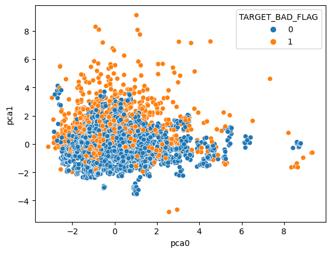

```python
sns.scatterplot(data=targetmerged2,x='pca0',y='pca1',hue='TARGET_BAD_FLAG')
```

```python
def transform_pca(X, n):

    pca = PCA(n_components=n)
    pca.fit(X)
    X_new = pca.inverse_transform(pca.transform(X))

    return X_new
```

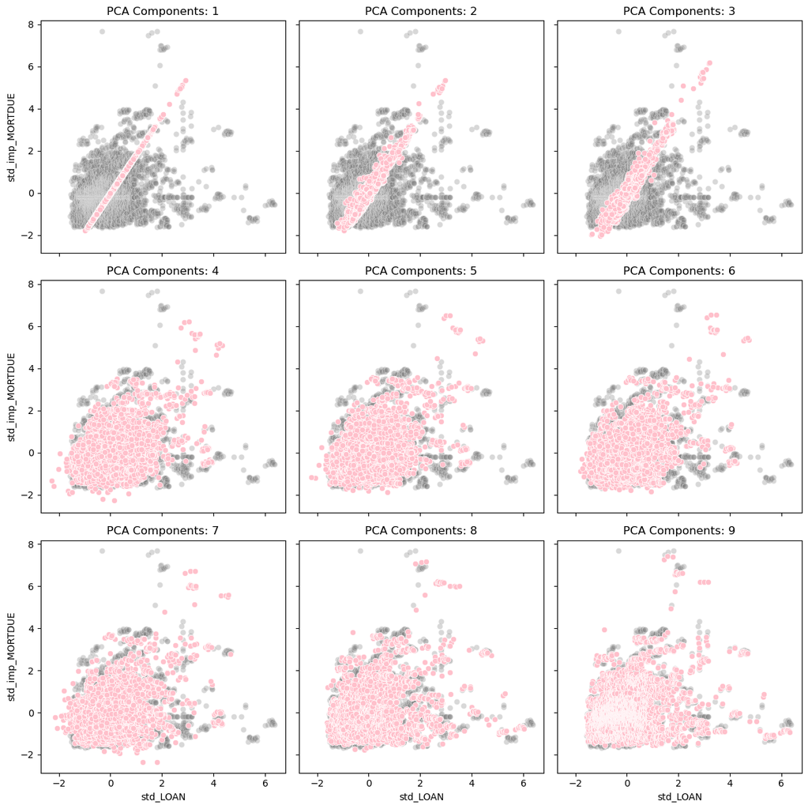

```python
rows = 3
cols = 3
comps = 1


fig, axes = plt.subplots(rows,
                         cols,
                         figsize=(12,12),
                         sharex=True,
                         sharey=True)


for row in range(rows):
    for col in range(cols):
        try:
            X_new = transform_pca(standardized,comps)
            ax = sns.scatterplot(x=standardized.iloc[:, 0],
                                 y=standardized.iloc[:, 1],
                                 ax=axes[row, col],
                                 color='grey',
                                 alpha=.3)
            ax = sns.scatterplot(x=X_new[:, 0],
                                 y=X_new[:, 1],
                                 ax=axes[row, col],
                                 color='pink')
            ax.set_title(f'PCA Components: {comps}');

            comps += 1
        except:
            pass
plt.tight_layout()
```

## Conclusion

Based on our PCA runs, we can definitively say that we can explain 98% of our variance with 9 components.

The final visualization showcases how well we can predict using 9 components. When looking at PCA Components: 1-3, we're really only able to predict in a linear fashion. As we get to 4-9 components we start being able to predict better and better. The pink dots should perfectly overlay the grey dots as the number of components increase.